# Is science broken?

## Echo in academia press

[figure not shown]

## Echo in non-academia press

[figure not shown]

# What is reproducible writing?

## Write plain text with computer code included

[figure not shown]

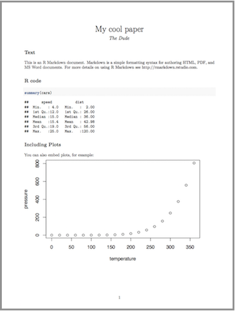

# Why should I write my paper in a reproducible manner?

## Re-do analysis with no pain

[figure not shown]

> Dude,  
> I sent you the wrong data. Find attached new dataset. You must re-do all analyses. Did I mention we submit tommorrow?  
> Regards,

> C. Kirk

## Match R code to results in paper easily

[figure not shown]

Paper with ~1,000 lines of wild R code.

In results section:  
“After some wild computation, we found accuracy to be **78%**…”

# How to do it?

## Process of repro paper writing

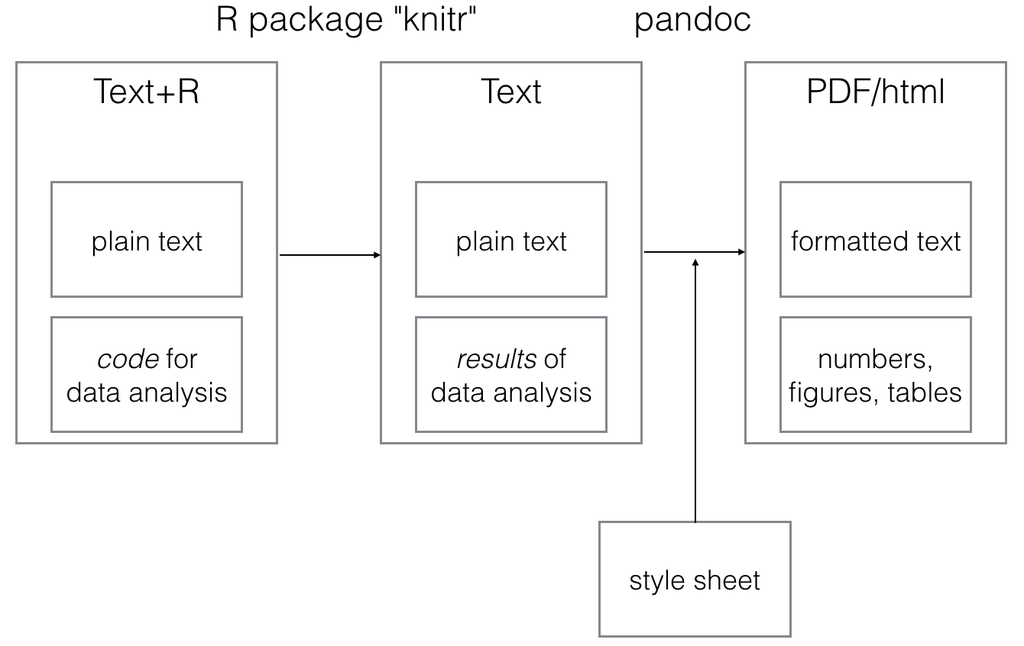

# Style sheets

## Style sheet for thesis/assignment

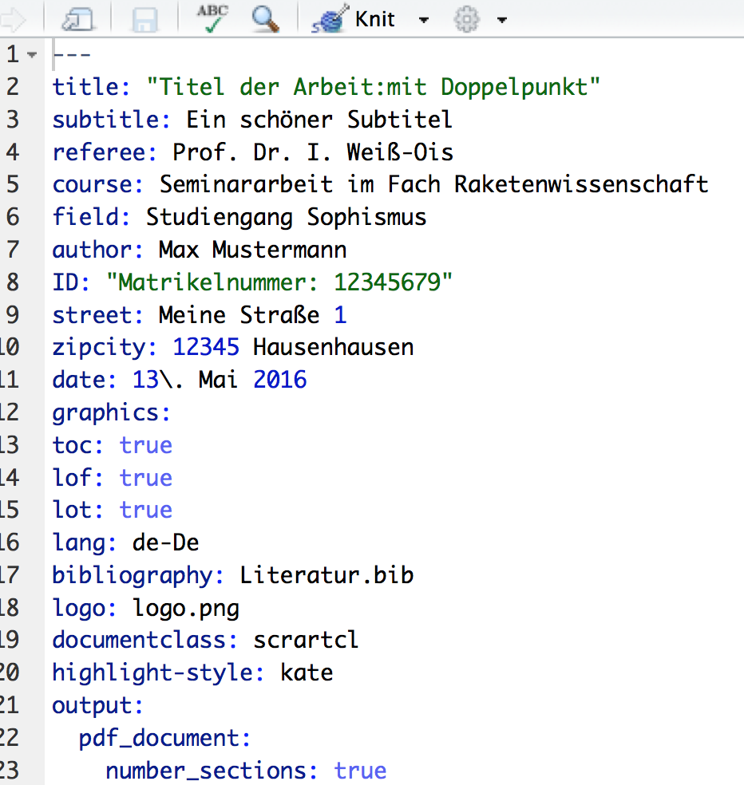

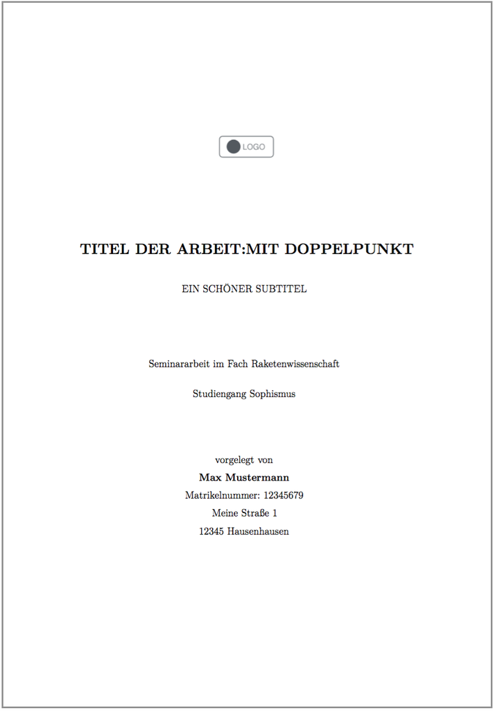

## Style sheet for APA papers

[Install PAPAJA](https://github.com/crsh/papaja) and open new APA template in RStudio

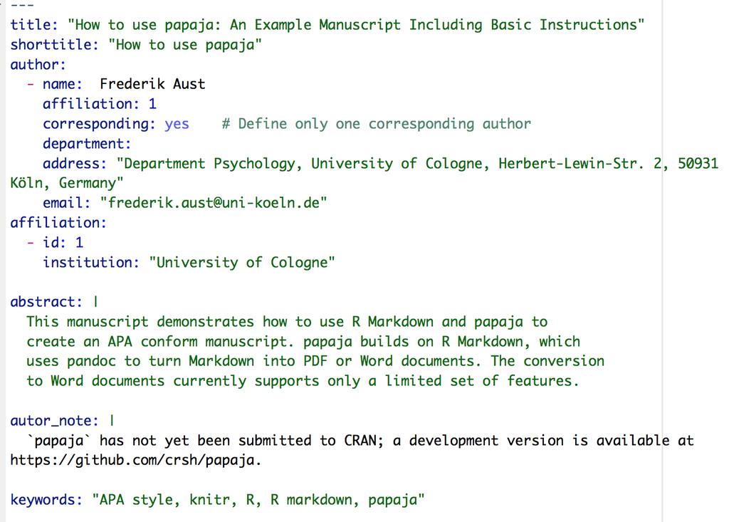

## Acknowledgments/ more infos

- Yihui Xie for`knitr` - http://kbroman.org/knitr_knutshell/
- John Gruber & Aaron Swartz for `markdown` - https://de.wikipedia.org/wiki/Markdown
- John MacFarlane for `pandoc` - http://pandoc.org
- RStudio team for `RStudio` - https://www.rstudio.com/home/
- R community for `R` - ttps://cran.r-project.org
- Frederik Aust for `papaja` - https://github.com/crsh/papaja
- Get my thesis template - https://github.com/sebastiansauer/Markdown_paper_template
- Github team for `github` - https://github.com
- Steven V. Miller for beamer template- https://github.com/svmiller/svm-r-markdown-templates

# That’s it

## Thank you

- **Get slides etc. of this talk here**: https://github.com/sebastiansauer/talk_repro_writing_DGPs_2016
- Contact:  
  Mail: sebastian.sauer@fom.de  
  Twitter: sauer_sebastian
[^1]: Slides on Github, http://bit.ly/29N7YH0